# ANOVA APPLICATION

## Objective:

The main objective of this work is to applied ANOVA test to explore the effect of three types of diet on losing weight. The data we have is from **kaggle** website https://www.kaggle.com/zaranadoshi/anova-diet

```r
library(tidyverse)
```

First, we should import data

```r
DataDiet=read.csv("~/Documents/master/s3/ANOVA/Diet.csv")
head(DataDiet)
```

```
##   gender Diet weight weight6weeks
## 1      M    B     60         60.0
## 2      M    B    103        103.0
## 3      F    A     58         54.2
## 4      F    A     60         54.0
## 5      F    A     64         63.3
## 6      F    A     64         61.1
```

We now create a new variable **weightlost = weight - weight6week** that indicating weight lost after 6 weeks of taking diet (a, b or c) in both men and women

```r
DataDiet=DataDiet %>% mutate(weightLost=weight-weight6weeks) %>% select(-3,-4)
head(DataDiet)
```

```
##   gender Diet weightLost
## 1      M    B        0.0
## 2      M    B        0.0
## 3      F    A        3.8
## 4      F    A        6.0
## 5      F    A        0.7
## 6      F    A        2.9
```

Let’s create a linear model that predicts weight loss based on diet and gender

```r
model=lm(weightLost~Diet*gender,data=DataDiet)
residus=residuals(model)
```

## Checking the conditions for applying ANOVA

### shapiro test to check normality.

The null hypothesis of this test is that the population comes from a normal distribution

```r
shapiro.test(residus)
```

```
##
##  Shapiro-Wilk normality test
##
## data:  residus
## W = 0.97983, p-value = 0.2527
```

Since the p-value is greater than alpha > 5%, so we accept the null hypothesis.\

We can also check the normality graphically using the histogram

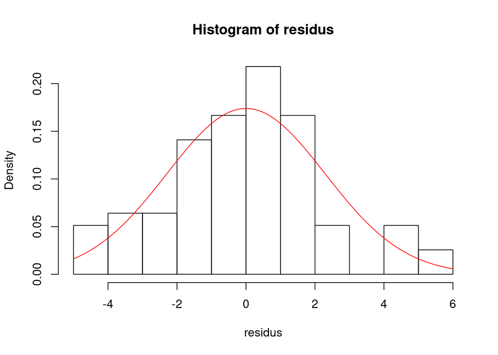

```r
hist(residus,prob='T')
curve(dnorm(x,mean(residus),sd(residus)),add=T,col="red")
```

### homocedacité test

The null hypothesis of this test is that the variance is the same in all samples.

```r
bartlett.test(residus~Diet,data=DataDiet)
```

```
##
##  Bartlett test of homogeneity of variances
##
## data:  residus by Diet
## Bartlett's K-squared = 0.38848, df = 2, p-value = 0.8235
```

```r
bartlett.test(residus~gender,data=DataDiet)
```

```
##
##  Bartlett test of homogeneity of variances
##
## data:  residus by gender
## Bartlett's K-squared = 2.3252, df = 1, p-value = 0.1273
```

We also accept the null hypothesis for both cases because the p-values are above the 5% range.

**Since the conditions are satisfied, we can apply the anova method on our data**

### anova table

```r
anova(model)
```

```
## Analysis of Variance Table
##
## Response: weightLost
##             Df Sum Sq Mean Sq F value   Pr(>F)
## Diet         2  71.09  35.547  6.3210 0.002957 **
## gender       1   0.14   0.136  0.0241 0.877067
## Diet:gender  2  25.14  12.570  2.2353 0.114336
## Residuals   72 404.90   5.624
## ---
## Signif. codes:  0 '***' 0.001 '**' 0.01 '*' 0.05 '.' 0.1 ' ' 1
```

The results of the **ANOVA** table means that the Diet variable is the only one that has an effect on weight loss, and there is no interaction between diet and gender variables

### Tukey test

We will now see which type of Diet is better for weight loss

```r
mod=aov(weightLost~Diet*gender,data=DataDiet)
TukeyHSD(mod,"Diet")
```

```
##   Tukey multiple comparisons of means
##     95% family-wise confidence level
##
## Fit: aov(formula = weightLost ~ Diet * gender, data = DataDiet)
##
## $Diet
##           diff        lwr      upr     p adj
## B-A -0.2740741 -1.8661803 1.318032 0.9108167
## C-A  1.8481481  0.2560420 3.440254 0.0188796
## C-B  2.1222222  0.5776524 3.666792 0.0044032
```

According to the results of calculations there is a significant deference between **C modality** and others

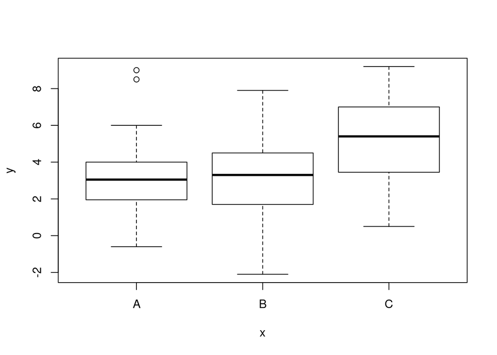

```r
plot(DataDiet$Diet,DataDiet$weightLost)
```

**Conclusion** The most suitable diet for losing weight is the C diet.